# Informe de Análisis del Mercado Inmobiliario en Cali

Juan José Restrepo Rosero

24 September 2024

# Introducción

En este informe se presenta un análisis descriptivo del mercado inmobiliario en la ciudad de Cali, basado en los datos recopilados por la empresa B&C.

# Objetivos

1. Analizar el precio de las viviendas en diferentes zonas de Cali.
2. Identificar el tipo de viviendas más ofertadas en Cali.
3. Determinar las características más relevantes de la oferta de vivienda en Cali.

# Métodos

Se utilizaron técnicas de análisis descriptivo para identificar tendencias y patrones en los datos.

# Resultados

```r
library(paqueteMETODOS)
library(tidyverse)
library(visdat)
library(naniar)
library(sf)
library(corrplot)
library(stats)
```

## Exploración Inicial de Datos

```r
data(vivienda_faltantes)
vivienda <- vivienda_faltantes
```

```r
head(vivienda)
```

| id | zona | piso | estrato | preciom | areaconst | parquea | banios | habitac | tipo | barrio | longitud | latitud |
| --- | --- | --- | --- | --- | --- | --- | --- | --- | --- | --- | --- | --- |
| 8312 | Zona Oeste | 4 | 6 | 1300 | 318 | 2 | 4 | 2 | Apartamento | arboleda | -76576 | 3454 |
| 8311 | Zona Oeste | 1 | 6 | 480 | 300 | 1 | 4 | 4 | Casa | normandía | -76571 | 3454 |
| 8307 | Zona Oeste | NA | 5 | 1200 | 800 | 4 | 7 | 5 | Casa | miraflores | -76568 | 3455 |
| 8296 | Zona Sur | 2 | 3 | 220 | 150 | 1 | 2 | 4 | Casa | el guabal | -76565 | 3417 |
| 8297 | Zona Oeste | NA | 5 | 330 | 112 | 2 | 4 | 3 | Casa | bella suiza alta | -76565 | 3408 |
| 8298 | Zona Sur | NA | 5 | 1350 | 390 | 8 | 10 | 10 | Casa | bella suiza alta | -76565 | 3409 |

```r
dim(vivienda)
```

```
## [1] 8330   13
```

```r
str(vivienda)
```

```
## spc_tbl_ [8,330 × 13] (S3: spec_tbl_df/tbl_df/tbl/data.frame)
##  $ id       : num [1:8330] 8312 8311 8307 8296 8297 ...
##  $ zona     : chr [1:8330] "Zona Oeste" "Zona Oeste" "Zona Oeste" "Zona Sur" ...
##  $ piso     : num [1:8330] 4 1 NA 2 NA NA 2 NA NA 2 ...
##  $ estrato  : num [1:8330] 6 6 5 3 5 5 6 5 5 5 ...
##  $ preciom  : num [1:8330] 1300 480 1200 220 330 1350 305 480 275 285 ...
##  $ areaconst: num [1:8330] 318 300 800 150 112 390 125 280 74 120 ...
##  $ parquea  : num [1:8330] 2 1 4 1 2 8 2 4 1 2 ...
##  $ banios   : num [1:8330] 4 4 7 2 4 10 3 4 2 4 ...
##  $ habitac  : num [1:8330] 2 4 5 4 3 10 3 4 3 3 ...
##  $ tipo     : chr [1:8330] "Apartamento" "Casa" "Casa" "Casa" ...
##  $ barrio   : chr [1:8330] "arboleda" "normandía" "miraflores" "el guabal" ...
##  $ longitud : num [1:8330] -76576 -76571 -76568 -76565 -76565 ...
##  $ latitud  : num [1:8330] 3454 3454 3455 3417 3408 ...
##  - attr(*, "spec")=
##   .. cols(
##   ..   id = col_double(),
##   ..   zona = col_character(),
##   ..   piso = col_double(),
##   ..   estrato = col_double(),
##   ..   preciom = col_double(),
##   ..   areaconst = col_double(),
##   ..   parquea = col_double(),
##   ..   banios = col_double(),
##   ..   habitac = col_double(),
##   ..   tipo = col_character(),
##   ..   barrio = col_character(),
##   ..   longitud = col_double(),
##   ..   latitud = col_double()
##   .. )
##  - attr(*, "problems")=<externalptr>
```

```r
summary(vivienda)
```

```
##        id           zona                piso           estrato
##  Min.   :   1   Length:8330        Min.   : 1.000   Min.   :3.000
##  1st Qu.:2082   Class :character   1st Qu.: 2.000   1st Qu.:4.000
##  Median :4164   Mode  :character   Median : 3.000   Median :5.000
##  Mean   :4164                      Mean   : 3.772   Mean   :4.634
##  3rd Qu.:6246                      3rd Qu.: 5.000   3rd Qu.:5.000
##  Max.   :8319                      Max.   :12.000   Max.   :6.000
##  NA's   :3                         NA's   :2641     NA's   :3
##     preciom         areaconst       parquea           banios
##  Min.   :  58.0   Min.   :  30   Min.   : 1.000   Min.   : 0.000
##  1st Qu.: 220.0   1st Qu.:  80   1st Qu.: 1.000   1st Qu.: 2.000
##  Median : 330.0   Median : 123   Median : 2.000   Median : 3.000
##  Mean   : 434.2   Mean   : 175   Mean   : 1.836   Mean   : 3.112
##  3rd Qu.: 540.0   3rd Qu.: 229   3rd Qu.: 2.000   3rd Qu.: 4.000
##  Max.   :1999.0   Max.   :1745   Max.   :10.000   Max.   :10.000
##  NA's   :2        NA's   :3      NA's   :1606     NA's   :3
##     habitac           tipo              barrio             longitud
##  Min.   : 0.000   Length:8330        Length:8330        Min.   :-76576.00
##  1st Qu.: 3.000   Class :character   Class :character   1st Qu.:-76506.00
##  Median : 3.000   Mode  :character   Mode  :character   Median :   -76.54
##  Mean   : 3.605                                         Mean   :-21845.13
##  3rd Qu.: 4.000                                         3rd Qu.:   -76.52
##  Max.   :10.000                                         Max.   :   -76.46
##  NA's   :3                                              NA's   :3
##     latitud
##  Min.   :   3.333
##  1st Qu.:   3.390
##  Median :   3.450
##  Mean   : 970.370
##  3rd Qu.:3367.000
##  Max.   :3497.000
##  NA's   :3
```

```r
colId <- vivienda$id
colZona <- vivienda$zona
colPiso <- vivienda$piso
colPrecio <- vivienda$preciom
colAreaCons <- vivienda$areaconst
colParque <- vivienda$parquea
colBanios <- vivienda$banios
colHabitac <- vivienda$habitac
colTipo <- vivienda$tipo
colBarrio <- vivienda$barrio
colLongitud <- vivienda$longitud
colLatitud <- vivienda$latitud
```

Al observar las primeras 6 filas del conjunto de datos, podemos ver que hay una variedad de tipos de propiedades, desde apartamentos hasta casas grandes, ubicadas en diferentes zonas de la ciudad. Los precios y las áreas construidas varían considerablemente.

## Consideraciones para el análisis posterior:

- Es importante notar que la variable zona y barrio pueden proporcionar información valiosa sobre la ubicación de las propiedades y su relación con el precio.
- Las coordenadas geográficas (longitud y latitud) permiten realizar análisis espaciales.
- Es necesario tratar los valores faltantes en las diferentes columnas.
- Será necesario identificar patrones y tendencias en los datos, como la relación entre el precio y el área construida, la distribución de los precios por zona, y la frecuencia de cada tipo de propiedad.

# Análisis Descriptivo

## Identificación de datos faltantes

```r
colSums(is.na(vivienda))
```

```
##        id      zona      piso   estrato   preciom areaconst   parquea    banios
##         3         3      2641         3         2         3      1606         3
##   habitac      tipo    barrio  longitud   latitud
##         3         3         3         3         3
```

Crearemos un dataframe con el número de valores faltantes por columna para visualizar la proporción de valores faltantes en cada columna

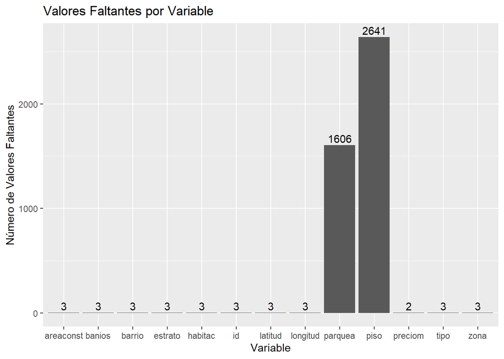

```r
faltantes <- colSums(is.na(vivienda))
faltantes <- data.frame(Variable = names(faltantes), Faltantes = faltantes)

ggplot(faltantes, aes(x = Variable, y = Faltantes)) +
  geom_bar(stat = "identity") +
  geom_text(aes(label = Faltantes), vjust = -0.3) +
  labs(title = "Valores Faltantes por Variable",
       x = "Variable",
       y = "Número de Valores Faltantes")
```

Para visualizar los patrones de datos faltantes y su relación con otras variables, utilizaremos las siguientes herramientas:

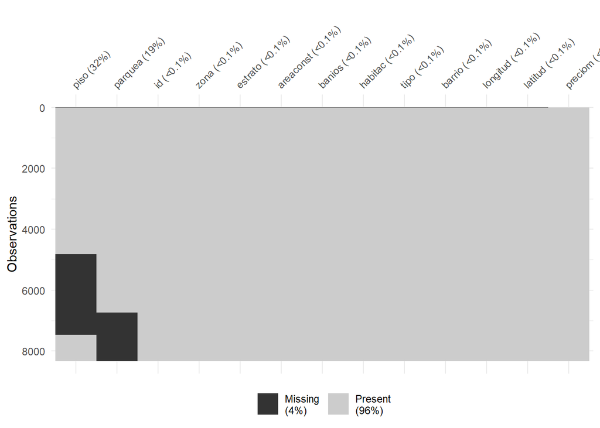

```r
vis_miss(vivienda, sort_miss = TRUE,
         cluster = TRUE)
```

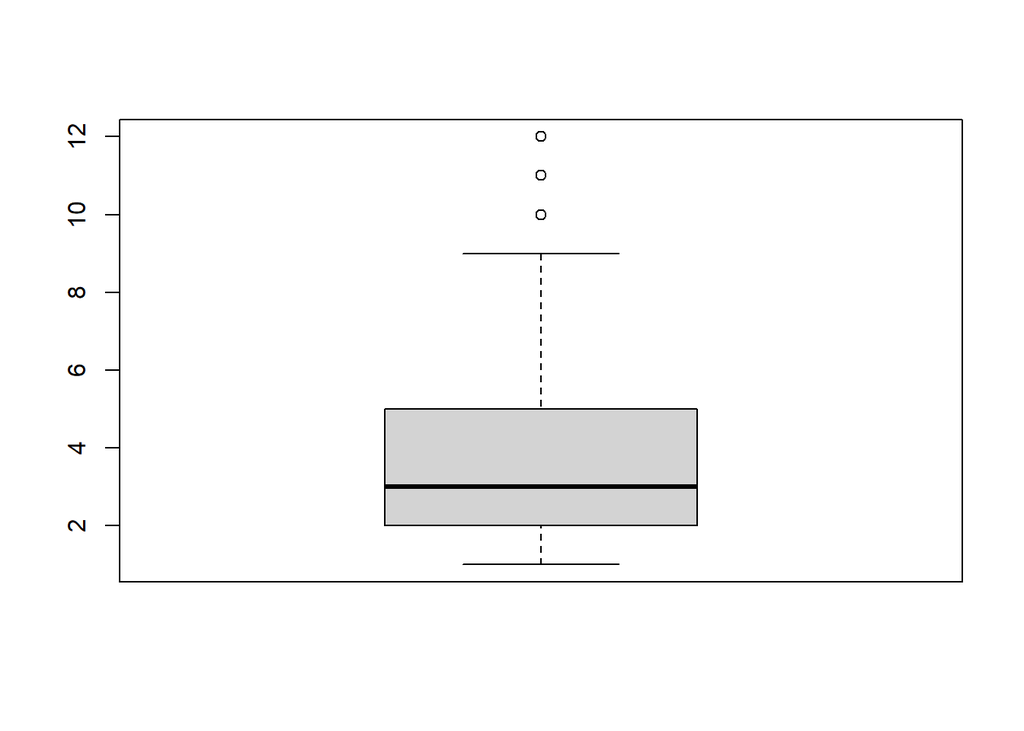

```r
boxplot(vivienda$piso)
```

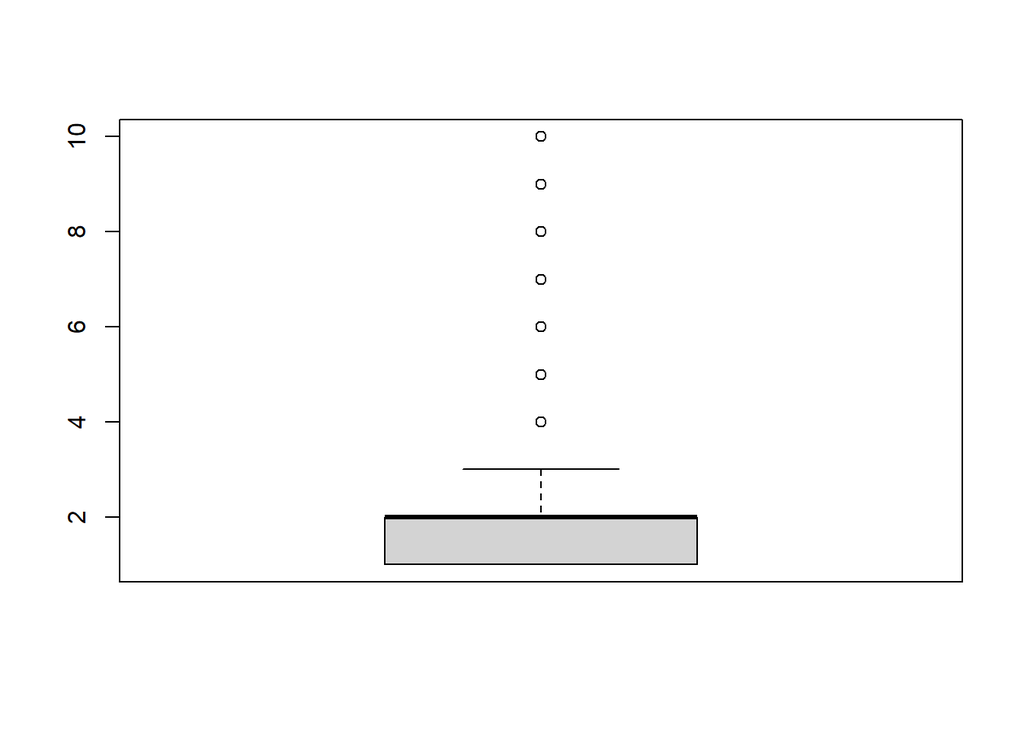

```r
boxplot(vivienda$parquea)
```

```r
which.min(vivienda$piso)
```

```
## [1] 2
```

```r
which.max(vivienda$piso)
```

```
## [1] 62
```

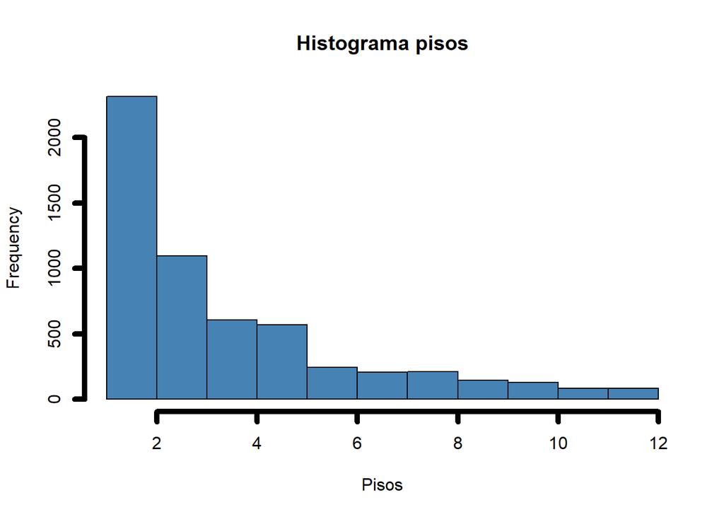

```r
hist(vivienda$piso,
     breaks = 10,
     col = "steelblue",
     pch = 19,
     lwd = 5,
     xlab = 'Pisos',
     main = "Histograma pisos")
```

#### Observaciones Generales:

Basándonos en el análisis previo, implementaremos las siguientes estrategias para manejar los valores faltantes:

### 1. Imputación de Valores Faltantes en Variables Numéricas

Para imputar los valores faltantes en las variables numéricas, utilizaremos la media de cada columna y redondearemos a enteros

```r
vivienda$piso[is.na(vivienda$piso)] <- round(mean(vivienda$piso, na.rm = TRUE))
vivienda$parquea[is.na(vivienda$parquea)] <- round(mean(vivienda$parquea, na.rm = TRUE))
```

### 2. Creación de Categoría para Variables Categóricas con Valores Faltantes

```r
vivienda$zona[is.na(vivienda$zona)] <- "Desconocido"
vivienda$barrio[is.na(vivienda$barrio)] <- "Desconocido"
```

Verificamos que se hayan realizado correctamente los cambios al tratar los datos faltantes

```r
head(vivienda)
```

| id | zona | piso | estrato | preciom | areaconst | parquea | banios | habitac | tipo | barrio | longitud | latitud |
| --- | --- | --- | --- | --- | --- | --- | --- | --- | --- | --- | --- | --- |
| 8312 | Zona Oeste | 4 | 6 | 1300 | 318 | 2 | 4 | 2 | Apartamento | arboleda | -76576 | 3454 |
| 8311 | Zona Oeste | 1 | 6 | 480 | 300 | 1 | 4 | 4 | Casa | normandía | -76571 | 3454 |
| 8307 | Zona Oeste | 4 | 5 | 1200 | 800 | 4 | 7 | 5 | Casa | miraflores | -76568 | 3455 |
| 8296 | Zona Sur | 2 | 3 | 220 | 150 | 1 | 2 | 4 | Casa | el guabal | -76565 | 3417 |
| 8297 | Zona Oeste | 4 | 5 | 330 | 112 | 2 | 4 | 3 | Casa | bella suiza alta | -76565 | 3408 |
| 8298 | Zona Sur | 4 | 5 | 1350 | 390 | 8 | 10 | 10 | Casa | bella suiza alta | -76565 | 3409 |

```r
colSums(is.na(vivienda))
```

```
##        id      zona      piso   estrato   preciom areaconst   parquea    banios
##         3         0         0         3         2         3         0         3
##   habitac      tipo    barrio  longitud   latitud
##         3         3         0         3         3
```

```r
dim(vivienda)
```

```
## [1] 8330   13
```

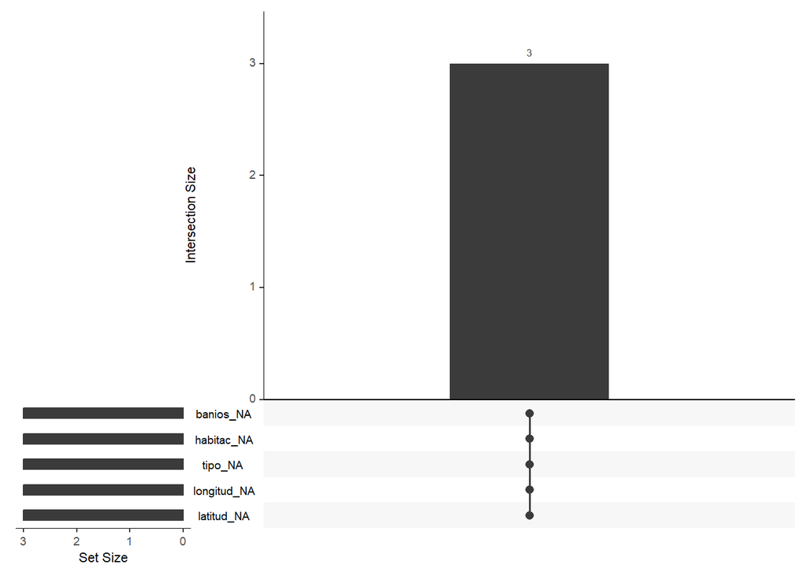

```r
vivienda %>% gg_miss_upset()
```

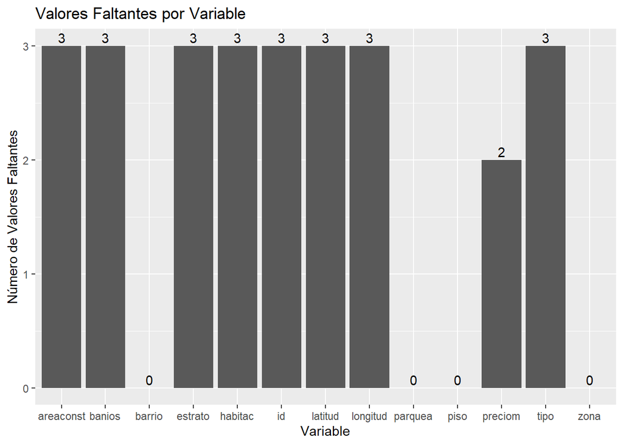

```r
faltantesActualizado <- colSums(is.na(vivienda))
faltantesActualizado <- data.frame(Variable = names(faltantesActualizado), Faltantes = faltantesActualizado)

ggplot(faltantesActualizado, aes(x = Variable, y = Faltantes)) +
  geom_bar(stat = "identity") +
  geom_text(aes(label = Faltantes), vjust = -0.3) +
  labs(title = "Valores Faltantes por Variable",
       x = "Variable",
       y = "Número de Valores Faltantes")
```

Aplicando imputación y creación de variables categóricas, se redujo significativamente la cantidad de datos faltantes. La imputación de la media para variables numéricas y la categoría ‘Desconocido’ para variables categóricas produjeron un conjunto de datos más completo.

## Frecuencia de tipos de vivienda

```r
table(vivienda$tipo)
```

```
##
## Apartamento APARTAMENTO        apto        casa        Casa        CASA
##        5032          61          13          14        3195          12
```

Si nos fijamos en los tipos de propiedades, vemos un pequeño error en cuanto a la división de los tipos de vivienda, en donde se registraron con diferentes nomenclaturas. Arreglaremos esto con un diccionario de sinónimos

### Diccionario de sinónimos

```r
sinonimos <- c("Apartamento" = "Apartamento", "APARTAMENTO" = "Apartamento",
               "apto" = "Apartamento", "casa" = "Casa", "Casa" = "Casa", "CASA" = "Casa")

# Reemplazar sinónimos en la columna "tipo"
vivienda$tipo <- plyr::revalue(vivienda$tipo, replace = sinonimos)
```

Verificamos que se hizo el cambio correctamente

```r
# Tabla de contingencia actualizada
table(vivienda$tipo)
```

```
##
## Apartamento        Casa
##        5106        3221
```

# Verificamos la relación entre los valores faltantes de ‘piso’ y el ‘tipo’

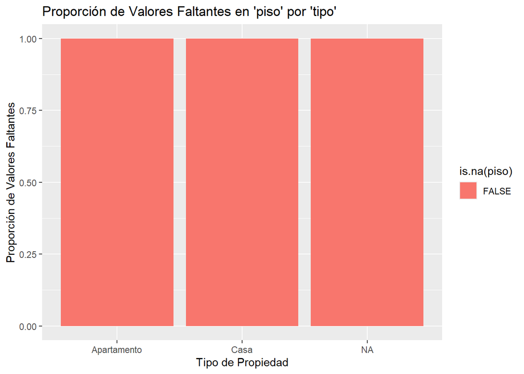

```r
ggplot(vivienda, aes(x = tipo, fill = is.na(piso))) +
  geom_bar(position = "fill") +
  labs(title = "Proporción de Valores Faltantes en 'piso' por 'tipo'",
       x = "Tipo de Propiedad",
       y = "Proporción de Valores Faltantes")
```

La gráfica anterior nos revela que, después de la imputación de datos, todas las categorías de `tipo` tienen una proporción de `0` en valores faltantes para `piso`, lo que significa que se ha logrado imputar correctamente todos los valores faltantes en dicha variable, eliminando cualquier `NA` en esa columna y demostrando la efectividad del proceso de imputación, sin diferencias en la proporción de valores faltantes entre los diferentes tipos de propiedades.

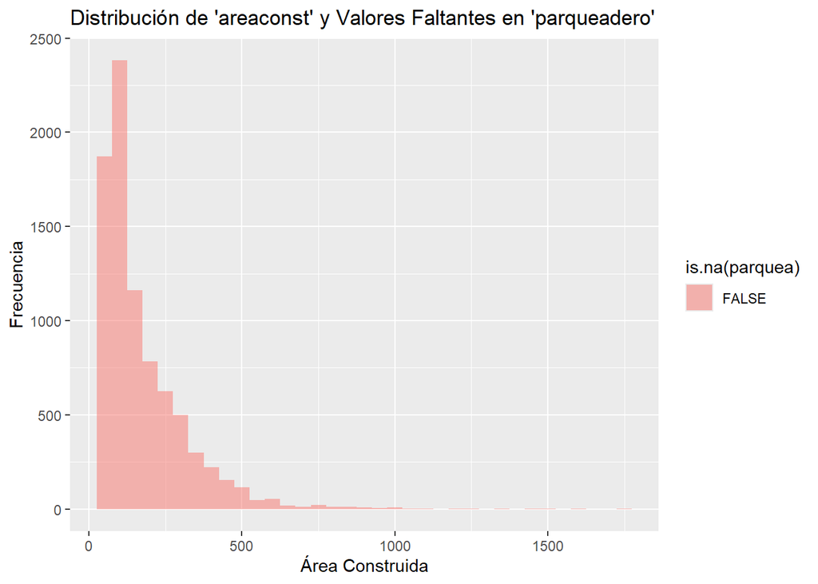

```r
# Verificar la relación entre los valores faltantes de 'parqueadero' y el 'area construida'
# Filtrar filas con valores no finitos en `areaconst`
vivienda <- vivienda %>% filter(is.finite(areaconst))

# Crear el histograma nuevamente
ggplot(vivienda, aes(x = areaconst, fill = is.na(parquea))) +
  geom_histogram(binwidth = 50, position = "identity", alpha = 0.5) +
  labs(title = "Distribución de 'areaconst' y Valores Faltantes en 'parqueadero'",
       x = "Área Construida",
       y = "Frecuencia")
```

La gráfica revela que la mayoría de las propiedades tienen áreas construidas pequeñas, con una frecuencia decreciente a medida que aumenta el área construida.

## Análisis de correlación

Calcularemos una matriz de correlación para identificar las variables que están más fuertemente relacionadas con el precio

```r
# Análisis de correlación
cor(vivienda[, c("preciom", "areaconst", "habitac", "banios")])
```

```
##             preciom areaconst   habitac    banios
## preciom   1.0000000 0.6872452 0.2633645 0.6691775
## areaconst 0.6872452 1.0000000 0.5166996 0.6486675
## habitac   0.2633645 0.5166996 1.0000000 0.5896911
## banios    0.6691775 0.6486675 0.5896911 1.0000000
```

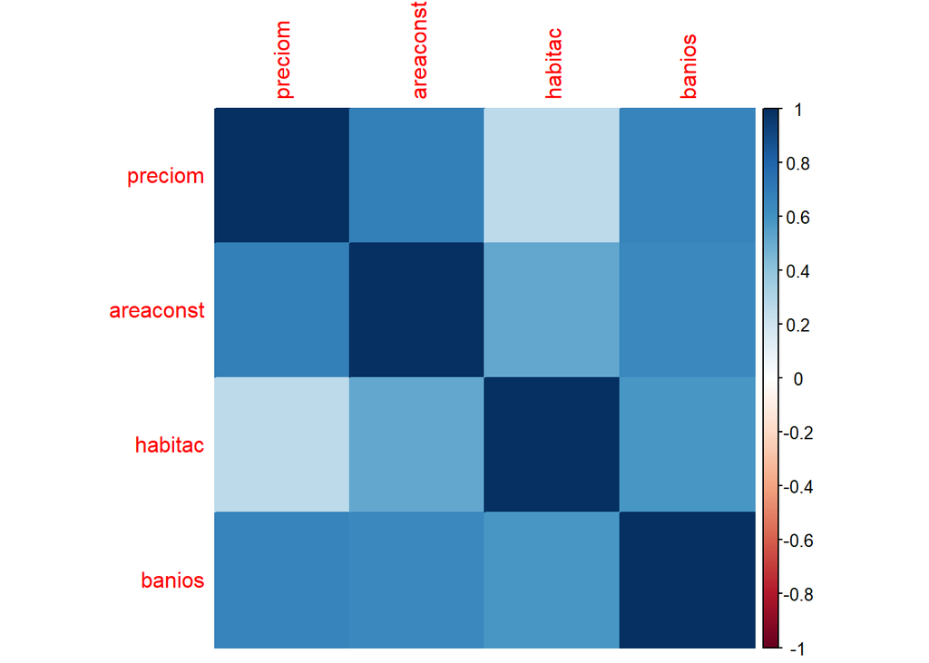

```r
# Mapa de calor de la matriz de correlación
corrplot(cor(vivienda[, c("preciom", "areaconst", "habitac", "banios")]), method = "color")
```

En base en estos análisis, se puede concluir que:

- El área construida es un predictor más fuerte del precio que el número de habitaciones. Ambos factores influyen positivamente en el precio de la propiedad.
- Se evidencia que la cantidad de baños también influye significativamente en el precio de las propiedades, junto con el área construida y el número de habitaciones.

## Análisis por zona

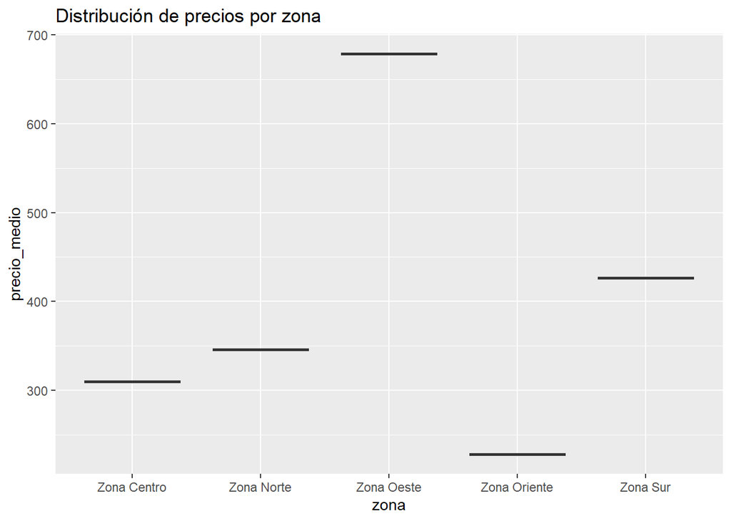

```r
# Agrupar por zona y calcular estadísticas descriptivas
vivienda_por_zona <- vivienda %>%
  group_by(zona) %>%
  summarize(precio_medio = mean(preciom),
            desv_std = sd(preciom))

# Gráfico de boxplot
ggplot(vivienda_por_zona, aes(x = zona, y = precio_medio)) +
  geom_boxplot() +
  labs(title = "Distribución de precios por zona")
```